### Fallou Diagne Data Scientist

# Contexte

L'objectif de ce document est de traiter et d'analyser le comportement des clients d'une banque enfin de prédire l'issue d'un énventuel crédit bancaire

- Etudier les liaisons entre les variables et la variable cible
- Visualiser les données
- Et préparer les données à une étude de ML pour une prédiction

Nous somme en présence de données réelles pour mieux axer l'analyse dans le milieu pratique.

NB: Vous pouvez toujours m'envoyé un mail pour toutes suggestions ou autres questions. *mail: diagneplus@gmail.com ou par Linkdln*

```python
# libraries de python
# Calcul et manipulation
import pandas as pd
import numpy as np

# graphiques
import seaborn as sns
import matplotlib.pyplot as plt
import plotly.offline as py
import plotly.graph_objs as go
from plotly.offline import download_plotlyjs, init_notebook_mode, plot, iplot
import plotly.tools as tls
import plotly.figure_factory as ff
py.init_notebook_mode(connected=True)
import squarify
plt.style.use('fivethirtyeight')
%matplotlib inline

# Dummification et imputatation
from sklearn.preprocessing import StandardScaler, LabelEncoder
from sklearn.model_selection import train_test_split #Partitionnement de la dataset
from sklearn.preprocessing import Imputer #Pour l'imputation des valeurs manquante

#Pas de message d'alertes
import warnings
warnings.filterwarnings('ignore')


pd.options.mode.chained_assignment = None  #masque les avertissements de pandas
```

```python
df=pd.read_excel('data_credit.xlsx')
```

Regardns notre dataset(en 5 ligne pa défaut)

```python
df.head()
```

|  | Comptes | Duree_credit | Historique_credit | Objet_credit | Montant_credit | Epargne | Anciennete_emploi | Taux_effort | Situation_familiale | Garanties | ... | Age | Autres_credits | Statut_domicile | Nb_credits | Type_emploi | Nb_pers_charge | Telephone | Etranger | Cible | ID |
| --- | --- | --- | --- | --- | --- | --- | --- | --- | --- | --- | --- | --- | --- | --- | --- | --- | --- | --- | --- | --- | --- |
| 0 | A11 | 6 | A34 | A43 | 1169 | A65 | A75 | 4 | A93 | A101 | ... | 67 | A143 | A152 | 2 | A173 | 1 | A192 | A201 | 1 | 1 |
| 1 | A12 | 48 | A32 | A43 | 5951 | A61 | A73 | 2 | A92 | A101 | ... | 22 | A143 | A152 | 1 | A173 | 1 | A191 | A201 | 2 | 2 |
| 2 | A14 | 12 | A34 | A46 | 2096 | A61 | A74 | 2 | A93 | A101 | ... | 49 | A143 | A152 | 1 | A172 | 2 | A191 | A201 | 1 | 3 |
| 3 | A11 | 42 | A32 | A42 | 7882 | A61 | A74 | 2 | A93 | A103 | ... | 45 | A143 | A153 | 1 | A173 | 2 | A191 | A201 | 1 | 4 |
| 4 | A11 | 24 | A33 | A40 | 4870 | A61 | A73 | 3 | A93 | A101 | ... | 53 | A143 | A153 | 2 | A173 | 2 | A191 | A201 | 2 | 5 |

5 rows × 22 columns

Dimension lignes*colonnes

```python
df.shape
```

```
(1000, 22)
```

L'ensemble des colonnes

```python
df.columns
```

```
Index(['Comptes', 'Duree_credit', 'Historique_credit', 'Objet_credit',
       'Montant_credit', 'Epargne', 'Anciennete_emploi', 'Taux_effort',
       'Situation_familiale', 'Garanties', 'Anciennete_domicile', 'Biens',
       'Age', 'Autres_credits', 'Statut_domicile', 'Nb_credits', 'Type_emploi',
       'Nb_pers_charge', 'Telephone', 'Etranger', 'Cible', 'ID'],
      dtype='object')
```

Assurons la conversion de la variable cible(variable à prédire également)

```python
df['Cible'] = df['Cible'].astype('object')
```

Description de la variable cible

```python
df['Cible'].describe(), df['Cible'].head()
```

```
(count     1000
 unique       2
 top          1
 freq       700
 Name: Cible, dtype: int64, 0    1
 1    2
 2    1
 3    1
 4    2
 Name: Cible, dtype: object)
```

Nous allons recodé le notre variable cible en 0/1 car il est codé en 1/2

```python
df['Cible'][df['Cible'] ==1 ] = '0'
df['Cible'][df['Cible'] ==2 ] = '1'
```

Vérification du recodage

```python
df['Cible'].describe(), df['Cible'].head()
```

```
(count     1000
 unique       2
 top          0
 freq       700
 Name: Cible, dtype: object, 0    0
 1    1
 2    0
 3    0
 4    1
 Name: Cible, dtype: object)
```

visualisons les types de l'ensemble des variables

```python
df.dtypes
```

```
Comptes                object
Duree_credit            int64
Historique_credit      object
Objet_credit           object
Montant_credit          int64
Epargne                object
Anciennete_emploi      object
Taux_effort             int64
Situation_familiale    object
Garanties              object
Anciennete_domicile     int64
Biens                  object
Age                     int64
Autres_credits         object
Statut_domicile        object
Nb_credits              int64
Type_emploi            object
Nb_pers_charge          int64
Telephone              object
Etranger               object
Cible                  object
ID                      int64
dtype: object
```

**Création de Métadonnées**

Pour faciliter la gestion des données, nous stockons des méta-informations sur les variables dans un DataFrame. Cela sera utile lorsque nous voudrons sélectionner des variables spécifiques pour l'analyse, la visualisation, la modélisation, etc. Nous notons que lorque les variables de la base sont nombreuses la création d'une métadonné reste capitale.

Concrètement nous allons stocker:

- level: nominal, interval, binaire
- Keep: True ou False
- dtype: int, object

```python
data = []
for f in df.columns:
    # Definissons le role
    if f == 'Cible':
        role = 'Cible'
    elif f == 'ID':
        role = 'id'
    else:
        role = 'input'

    # Définition du niveau des variables
    if  f == 'Cible':
        level = 'binary'
    elif  f == 'ID':
        level = 'nominal'
    elif df[f].dtypes == 'object':
        level = 'nominal'
    elif df[f].dtypes == 'int':
        level = 'interval'

    #On initialise Keep à True pour toutes les variables sauf id
    keep = True
    if f == 'ID':
        keep = False

    # définition du type
    dtype = df[f].dtype

    # Créer un Dict contenant toutes les métadonnées de la variable
    f_dict = {
        'varname': f,
        'role': role,
        'level': level,
        'keep': keep,
        'dtype': dtype
    }
    data.append(f_dict)

meta = pd.DataFrame(data, columns=['varname', 'role', 'level', 'keep', 'dtype'])
meta.set_index('varname', inplace=True)
```

Nous allons voir maintenant notre dico

```python
meta
```

| varname | role | level | keep | dtype |
| --- | --- | --- | --- | --- |
| Comptes | input | nominal | True | object |
| Duree_credit | input | interval | True | int64 |
| Historique_credit | input | nominal | True | object |
| Objet_credit | input | nominal | True | object |
| Montant_credit | input | interval | True | int64 |
| Epargne | input | nominal | True | object |
| Anciennete_emploi | input | nominal | True | object |
| Taux_effort | input | interval | True | int64 |
| Situation_familiale | input | nominal | True | object |
| Garanties | input | nominal | True | object |
| Anciennete_domicile | input | interval | True | int64 |
| Biens | input | nominal | True | object |
| Age | input | interval | True | int64 |
| Autres_credits | input | nominal | True | object |
| Statut_domicile | input | nominal | True | object |
| Nb_credits | input | interval | True | int64 |
| Type_emploi | input | nominal | True | object |
| Nb_pers_charge | input | interval | True | int64 |
| Telephone | input | nominal | True | object |
| Etranger | input | nominal | True | object |
| Cible | Cible | binary | True | object |
| ID | id | nominal | False | int64 |

L'ensemble des variables qualitatives

```python
meta[(meta.level == 'nominal') & (meta.keep)].index
```

```
Index(['Comptes', 'Historique_credit', 'Objet_credit', 'Epargne',
       'Anciennete_emploi', 'Situation_familiale', 'Garanties', 'Biens',
       'Autres_credits', 'Statut_domicile', 'Type_emploi', 'Telephone',
       'Etranger'],
      dtype='object', name='varname')
```

Lensemble des variables quantitatives

```python
meta[(meta.level == 'interval') & (meta.keep)].index
```

```
Index(['Duree_credit', 'Montant_credit', 'Taux_effort', 'Anciennete_domicile',
       'Age', 'Nb_credits', 'Nb_pers_charge'],
      dtype='object', name='varname')
```

Nombre de variable par role et niveau

```python
pd.DataFrame({'count' : meta.groupby(['role', 'level'])['role'].size()}).reset_index()
```

|  | role | level | count |
| --- | --- | --- | --- |
| 0 | Cible | binary | 1 |
| 1 | id | nominal | 1 |
| 2 | input | interval | 7 |
| 3 | input | nominal | 13 |

Nous pouvons également appliquer la méthode describe sur le dataframe.

Grâce à notre métadonnée, nous pouvons facilement sélectionner les variables sur lesquelles nous voulons calculer les statistiques descriptives. Pour que tout soit clair, nous allons le faire par type de données.

Description des variables quantitatives

```python
v = meta[(meta.level == 'interval') & (meta.keep)].index
df[v].describe().transpose()
```

|  | count | mean | std | min | 25% | 50% | 75% | max |
| --- | --- | --- | --- | --- | --- | --- | --- | --- |
| Duree_credit | 1000.0 | 20.903 | 12.058814 | 4.0 | 12.0 | 18.0 | 24.00 | 72.0 |
| Montant_credit | 1000.0 | 3271.258 | 2822.736876 | 250.0 | 1365.5 | 2319.5 | 3972.25 | 18424.0 |
| Taux_effort | 1000.0 | 2.973 | 1.118715 | 1.0 | 2.0 | 3.0 | 4.00 | 4.0 |
| Anciennete_domicile | 1000.0 | 2.845 | 1.103718 | 1.0 | 2.0 | 3.0 | 4.00 | 4.0 |
| Age | 1000.0 | 26.427 | 18.498185 | -1.0 | 20.0 | 28.0 | 38.00 | 75.0 |
| Nb_credits | 1000.0 | 1.407 | 0.577654 | 1.0 | 1.0 | 1.0 | 2.00 | 4.0 |
| Nb_pers_charge | 1000.0 | 1.155 | 0.362086 | 1.0 | 1.0 | 1.0 | 1.00 | 2.0 |

Description des variables qualitatives

```python
v = meta[(meta.level == 'nominal') & (meta.keep)].index
df[v].describe().transpose()
```

|  | count | unique | top | freq |
| --- | --- | --- | --- | --- |
| Comptes | 1000 | 4 | A14 | 394 |
| Historique_credit | 1000 | 5 | A32 | 530 |
| Objet_credit | 1000 | 11 | -1 | 262 |
| Epargne | 1000 | 5 | A61 | 603 |
| Anciennete_emploi | 1000 | 5 | A73 | 339 |
| Situation_familiale | 1000 | 4 | A93 | 548 |
| Garanties | 1000 | 3 | A101 | 907 |
| Biens | 1000 | 4 | A123 | 332 |
| Autres_credits | 1000 | 3 | A143 | 814 |
| Statut_domicile | 1000 | 4 | A152 | 562 |
| Type_emploi | 1000 | 4 | A173 | 630 |
| Telephone | 1000 | 3 | A191 | 442 |
| Etranger | 1000 | 3 | -1 | 609 |

Description de la variables Cible:

```python
v = meta[(meta.level == 'binary') & (meta.keep)].index
df[v].describe().transpose()
```

|  | count | unique | top | freq |
| --- | --- | --- | --- | --- |
| Cible | 1000 | 2 | 0 | 700 |

*Etude des valeurs manquantes*

Cette algorithme nous donne informations sur les valeurs manquantes de chaque variable dans notre dataset.

*Attention*: les valeurs manquantes sont codées en *-1*

```python
vars_with_missing = []

for f in df.columns:
    missings = df[df[f] == -1][f].count()
    if missings > 0:
        vars_with_missing.append(f)
        missings_perc = missings/df.shape[0]

        print('Variable {} has {} records ({:.2%}) with missing values'.format(f, missings, missings_perc))

print('En total, il a {} variables avec des valeurs manquantes'.format(len(vars_with_missing)))
```

```
Variable Objet_credit has 262 records (26.20%) with missing values
Variable Age has 247 records (24.70%) with missing values
Variable Statut_domicile has 218 records (21.80%) with missing values
Variable Telephone has 250 records (25.00%) with missing values
Variable Etranger has 609 records (60.90%) with missing values
En total, il a 5 variables avec des valeurs manquantes
```

La variable Etranger a 60.90% de valeurs manquantes, alors nous décidons de la supprimer de la base.

```python
#Si nous avions plusieurs variables à supprimer nous pourrions les regrouper
#dans "vars_to_drop" très pratique n'est ce pas !
vars_to_drop = ['Etranger']
df.drop(vars_to_drop, inplace=True, axis=1)
meta.loc[(vars_to_drop),'keep'] = False  # mise à jour le dataframme crée(meta)
```

*Imputation des valeurs manquantes*

Nous avons alors 4 variables à imputer, l'une est l'Age et les trois autres sont Statut_domicile, Objet_credit, Telephone

```python
df['Statut_domicile'] = df['Statut_domicile'].astype('object')
df['Objet_credit'] = df['Objet_credit'].astype('object')
df['Telephone'] = df['Telephone'].astype('object')
```

- Imputation de la variables quatitative "Age" par sa moyenne

```python
mean_imp = Imputer(missing_values=-1, strategy='mean', axis=0)
df['Age'] = mean_imp.fit_transform(df[['Age']]).ravel()
```

- Imputation des variables qualitatives par leur mode

```python
df['Telephone'][df['Telephone'] ==-1 ] =df['Telephone'].mode()
df['Objet_credit'][df['Objet_credit'] ==-1 ] =df['Objet_credit'].mode()
df['Statut_domicile'][df['Statut_domicile'] ==-1 ] =df['Statut_domicile'].mode()
```

Vérification de l'application de l'imputation sur les variables concernées

```python
vars_with_missing = []

for f in df.columns:
    missings = df[df[f] == -1][f].count()
    if missings > 0:
        vars_with_missing.append(f)
        missings_perc = missings/df.shape[0]

        print('Variable {} has {} records ({:.2%}) with missing values'.format(f, missings, missings_perc))

print('En total, il a {} variables avec des valeurs manquantes'.format(len(vars_with_missing)))
```

```
En total, il a 0 variables avec des valeurs manquantes
```

Revoir notra dataset pour s'assurer que tout va bien

```python
df.head()
```

|  | Comptes | Duree_credit | Historique_credit | Objet_credit | Montant_credit | Epargne | Anciennete_emploi | Taux_effort | Situation_familiale | Garanties | ... | Biens | Age | Autres_credits | Statut_domicile | Nb_credits | Type_emploi | Nb_pers_charge | Telephone | Cible | ID |
| --- | --- | --- | --- | --- | --- | --- | --- | --- | --- | --- | --- | --- | --- | --- | --- | --- | --- | --- | --- | --- | --- |
| 0 | A11 | 6 | A34 | A43 | 1169 | A65 | A75 | 4 | A93 | A101 | ... | A121 | 67.0 | A143 | A152 | 2 | A173 | 1 | A192 | 0 | 1 |
| 1 | A12 | 48 | A32 | A43 | 5951 | A61 | A73 | 2 | A92 | A101 | ... | A121 | 22.0 | A143 | A152 | 1 | A173 | 1 | A191 | 1 | 2 |
| 2 | A14 | 12 | A34 | A46 | 2096 | A61 | A74 | 2 | A93 | A101 | ... | A121 | 49.0 | A143 | A152 | 1 | A172 | 2 | A191 | 0 | 3 |
| 3 | A11 | 42 | A32 | A42 | 7882 | A61 | A74 | 2 | A93 | A103 | ... | A122 | 45.0 | A143 | A153 | 1 | A173 | 2 | A191 | 0 | 4 |
| 4 | A11 | 24 | A33 | A40 | 4870 | A61 | A73 | 3 | A93 | A101 | ... | A124 | 53.0 | A143 | A153 | 2 | A173 | 2 | A191 | 1 | 5 |

5 rows × 21 columns

*Vérification de la cardinalité des variables catégoriques*

La cardinalité fait référence au nombre de valeurs différentes dans une variable. Comme nous allons créer des variables nominales à partir des variables qualitatives, nous devons vérifier s’il existe des variables avec beaucoup de valeurs distinctes. Nous devrions traiter ces variables différemment car elles donneraient lieu à de nombreuses variables nominales.

```python
v = meta[(meta.level == 'nominal') & (meta.keep)].index
for f in v:
    dist_values = df[f].value_counts().shape[0]
    print('La variable {} a {} modalités'.format(f, dist_values))
```

```
La variable Comptes a 4 modalités
La variable Historique_credit a 5 modalités
La variable Objet_credit a 10 modalités
La variable Epargne a 5 modalités
La variable Anciennete_emploi a 5 modalités
La variable Situation_familiale a 4 modalités
La variable Garanties a 3 modalités
La variable Biens a 4 modalités
La variable Autres_credits a 3 modalités
La variable Statut_domicile a 3 modalités
La variable Type_emploi a 4 modalités
La variable Telephone a 2 modalités
```

Seule la variable Objet_credit posséde 10 modalités et c'est raisonnable pour cette variable.

# Visualisation des données

# Zoom sur les variables quantitatives

Nous allons visualiser en graphiques l'ordre de grandeur des variables quantitatives et leur statistiques de base

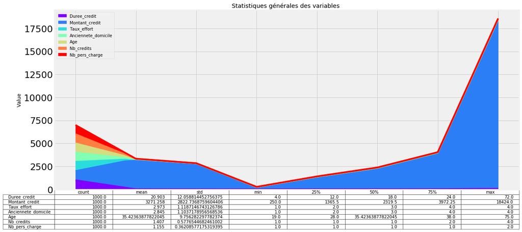

```python
df_qual=df.select_dtypes(exclude=['object'])
df_qual.drop('ID', axis=1, inplace=True)
df_qual.describe().plot(kind = "area",fontsize=22, figsize = (18,8), table = True,colormap="rainbow")
plt.xlabel('',)
plt.ylabel('Value')
plt.title("Statistiques générales des variables ")
```

*Zoom sur notre variables cibles*

Nous voyons bien que 30% des clients de notr datasets n'ont payé leur crédit.

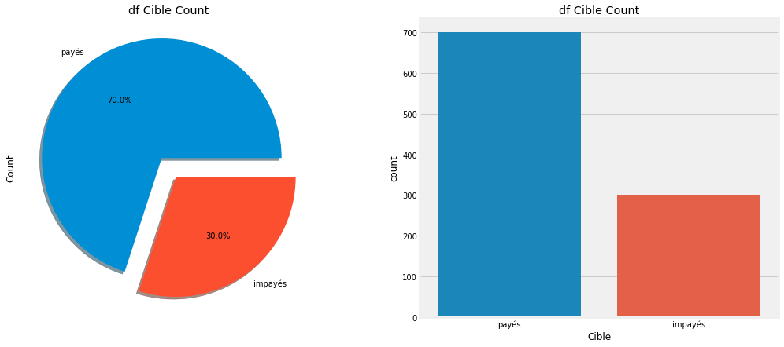

```python
df['Cible'][df['Cible'] =='0' ] = 'payés'
df['Cible'][df['Cible'] =='1' ] = 'impayés'
f,ax=plt.subplots(1,2,figsize=(16,7))
df['Cible'].value_counts().plot.pie(explode=[0.1,0.1],autopct='%1.1f%%',ax=ax[0],shadow=True)
ax[0].set_title('df Cible Count')
ax[0].set_ylabel('Count')
sns.countplot('Cible',data=df,ax=ax[1])
ax[1].set_title('df Cible Count')
plt.show()
```

Voyons comment les clients se sont réparties autours des variables quantitaive discriminé par la variables à prédire

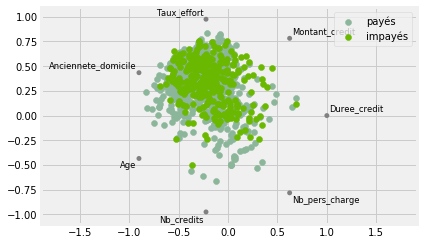

```python
df_cont = df[['Duree_credit', 'Montant_credit', 'Taux_effort', 'Anciennete_domicile',
       'Age', 'Nb_credits', 'Nb_pers_charge', 'Cible']]
from pandas.tools.plotting import radviz
radviz(df_cont,"Cible")
```

On peut vrément avoir une petite idée sur l'importance des variables sur notre variable cible. Le montant de credit, le taux d'effort, ancienneté et la durée de credit semblent etre des variables plus importantes, Nous allons vérifié ceci, et axé plus l'étude descriptive sur ces variables en liason avec notre variable à prédire

Boxplot de quelques variables selon les types de paiment

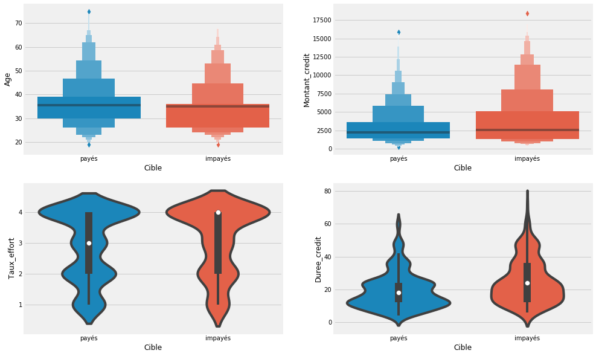

```python
plt.figure(figsize=(15,10))
plt.subplot(2,2,1)
sns.boxenplot(x='Cible',y='Age',data=df)
plt.subplot(2,2,2)
sns.boxenplot(x='Cible',y='Montant_credit',data=df)
plt.subplot(2,2,3)
sns.violinplot(x='Cible',y='Taux_effort',data=df)
plt.subplot(2,2,4)
sns.violinplot(x='Cible',y='Duree_credit',data=df)
```

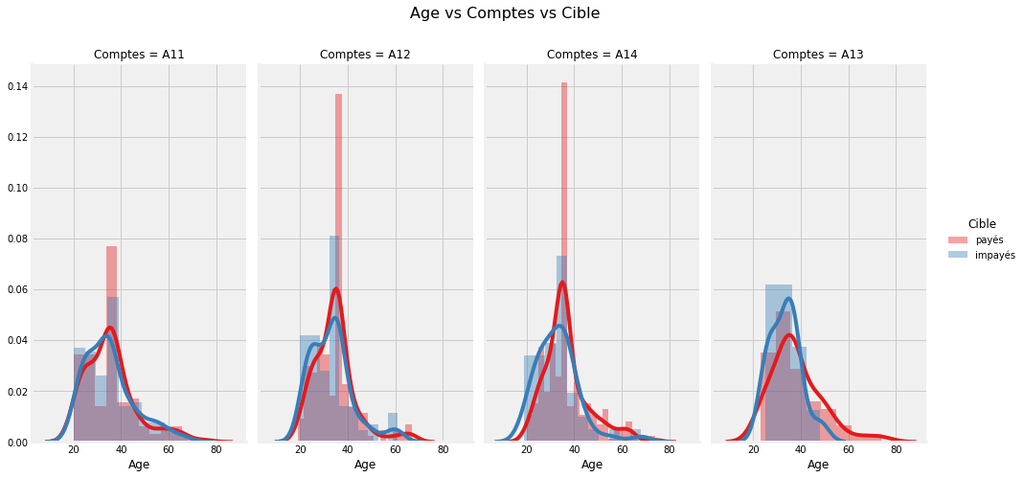

```python
g = sns.FacetGrid(df, col="Comptes", hue="Cible", palette="Set1")
g.map(sns.distplot, "Age")
g = g.add_legend()
g.fig.suptitle('Age vs Comptes vs Cible', fontsize=16)
g.fig.set_size_inches(15,8)
```